# Project2

# LOGISTIC REGRESSION MODEL

```r
comparisonfiltering$won <- factor(comparisonfiltering$won)  #make rank a factor

fit3 <- glm(won ~ goals + passes + crosses, data = comparisonfiltering,
    family = "binomial")
coeftest(fit3)
```

```
##
## z test of coefficients:
##
##             Estimate Std. Error z value  Pr(>|z|)
## (Intercept) -0.78633    0.16792 -4.6827 2.831e-06 ***
## goals        0.21285    0.16185  1.3151    0.1885
## passes       0.16735    0.18572  0.9011    0.3675
## crosses     -0.19004    0.19937 -0.9532    0.3405
## ---
## Signif. codes:  0 '***' 0.001 '**' 0.01 '*' 0.05 '.' 0.1 ' ' 1
```

```r
# original scale (log-odds scale)
coef(fit3) %>% round(3) %>% data.frame
```

```
##                  .
## (Intercept) -0.786
## goals        0.213
## passes       0.167
## crosses     -0.190
```

```r
# exponentiated (odds scale)
exp(coef(fit3)) %>% round(3) %>% data.frame
```

```
##                 .
## (Intercept) 0.456
## goals       1.237
## passes      1.182
## crosses     0.827
```

```r
prob <- predict(fit3, type = "response")  #get predictions for every student in the dataset
# pred<-ifelse(prob>.5,1,0)
table(predict = as.numeric(prob > 0.5), truth = comparisonfiltering$won) %>%
    addmargins
```

```
##        truth
## predict   0   1 Sum
##     0   113  53 166
##     1     2   0   2
##     Sum 115  53 168
```

```r
# table(truth=comparisonfiltering$won,
# prediction=pred)%>%addmargins
(251 + 27)/400  #accuracy
```

```
## [1] 0.695
```

```r
27/127  #tpr
```

```
## [1] 0.2125984
```

```r
251/273  #tnr
```

```
## [1] 0.9194139
```

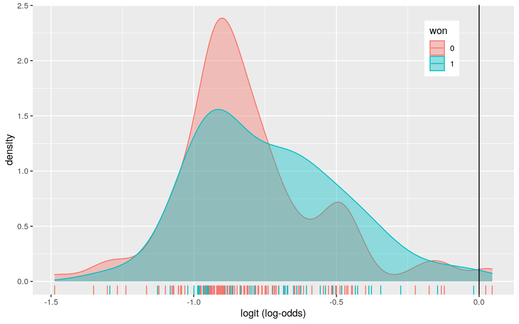

```r
comparisonfiltering$logit <- predict(fit3, type = "link")

comparisonfiltering %>% ggplot() + geom_density(aes(logit, color = won,
    fill = won), alpha = 0.4) + theme(legend.position = c(0.85,
    0.85)) + geom_vline(xintercept = 0) + xlab("logit (log-odds)") +
    geom_rug(aes(logit, color = won))
```

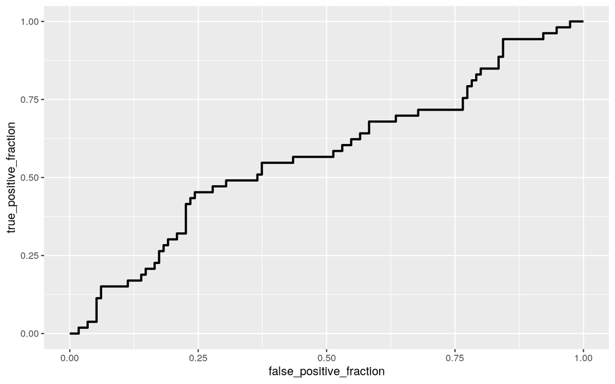

```r
# table(predict=as.numeric(comparisonsfiltering$prob>.1),truth=comparisonsfiltering$won)

library(plotROC)  #install.packages(plotROC)

# geom_roc needs true outcome (d, should be 0/1) and
# predicted probability/logit (m, or just predictor if just
# one):
ROCplot <- ggplot(comparisonsfiltering) + geom_roc(aes(d = won,
    m = prob), n.cuts = 0)

ROCplot
```

```r
# as soon as you build your ROC curve, you can compute the
# AUC with
calc_auc(ROCplot)
```

```
##   PANEL group       AUC
## 1     1    -1 0.5707957
```

With only the intercept coefficient being significant, the goals, passes, and crosses per individual did not have a significant effect on whether the team would win the world cup that year, at least in comparison to two of the other best teams in the world. Goals and passes, if significant, would have brought the team closer to winning whereas crosses had a much lower estimate on winning showing what factored more into getting the gold. With a final AUC of 0.571, our model was not very good at predicting whether or not the team would win from these three factors.

```r
# LEAVE THIS CHUNK ALONE!
library(knitr)
opts_chunk$set(fig.align = "center", fig.height = 5, message = FALSE,
    warning = FALSE, fig.width = 8, tidy.opts = list(width.cutoff = 60),
    tidy = TRUE)

# HERE'S THE CLASSIFICAITON DIAGNOSTICS FUNCTION
class_diag <- function(probs, truth) {
    tab <- table(factor(probs > 0.5, levels = c("FALSE", "TRUE")),
        truth)
    acc = sum(diag(tab))/sum(tab)
    sens = tab[2, 2]/colSums(tab)[2]
    spec = tab[1, 1]/colSums(tab)[1]
    ppv = tab[2, 2]/rowSums(tab)[2]
    f1 = 2 * (sens * ppv)/(sens + ppv)

    if (is.numeric(truth) == FALSE & is.logical(truth) == FALSE) {
        truth <- as.numeric(truth) - 1
    }

    # CALCULATE EXACT AUC
    ord <- order(probs, decreasing = TRUE)
    probs <- probs[ord]
    truth <- truth[ord]

    TPR = cumsum(truth)/max(1, sum(truth))
    FPR = cumsum(!truth)/max(1, sum(!truth))

    dup <- c(probs[-1] >= probs[-length(probs)], FALSE)
    TPR <- c(0, TPR[!dup], 1)
    FPR <- c(0, FPR[!dup], 1)

    n <- length(TPR)
    auc <- sum(((TPR[-1] + TPR[-n])/2) * (FPR[-1] - FPR[-n]))

    data.frame(acc, sens, spec, ppv, f1, auc)
}

fit5 <- glm(won ~ ., data = comparisonfiltering, family = "binomial",
    control = list(maxit = 50))
prob <- predict(fit5, type = "response")
class_diag(prob, comparisonfiltering$won)
```

```
##   acc sens spec ppv f1 auc
## 1   1    1    1   1  1   1
```

```r
table(predict = as.numeric(prob > 0.5), truth = comparisonsfiltering$won) %>%
    addmargins
```

```
##        truth
## predict   0   1 Sum
##     0   115   0 115
##     1     0  53  53
##     Sum 115  53 168
```

```r
k = 10
data <- comparisonfiltering %>% sample_frac  #put rows of dataset in random order
folds <- ntile(1:nrow(data), n = 10)  #create fold labels
diags <- NULL
# for(i in 1:k){ train <- data[folds!=i,] #create training
# set (all but fold i) test <- data[folds==i,] #create test
# set (just fold i) truth <- test$won #save truth labels from
# fold i
# fit<-glm(won~.,data=comparisonfiltering,family='binomial',control
# = list(maxit = 50)) prob<-predict(fit,newdata =
# test,type='response')
# diags<-rbind(diags,class_diag(prob,truth)) }
# summarize_all(diags,mean)


library(glmnet)
y <- as.matrix(comparisonfiltering$won)
comp_preds <- model.matrix(won ~ -1 + ., data = comparisonfiltering)
head(comp_preds)
```

[output not shown]

[output cut: 251 more lines]

```r
x <- scale(comp_preds)

cv <- cv.glmnet(comp_preds, y, family = "binomial")
lasso_fit <- glmnet(comp_preds, y, family = "binomial", lambda = cv$lambda.1se)
coef(lasso_fit)
```

```
## 140 x 1 sparse Matrix of class "dgCMatrix"
##                                         s0
## (Intercept)                  -2.991763e+03
## playerAbou Diaby              .
## playerAlou Diarra             .
## playerAndré Schürrle          6.410666e-01
## playerAndré-Pierre Gignac     .
## playerAndrés Iniesta          .
## playerAntoine Griezmann       .
## playerAntonio Rüdiger         .
## playerArne Friedrich         -8.974782e-01
## playerBacary Sagna            .
## playerBastian Schweinsteiger  .
## playerBenedikt Höwedes        5.490815e-01
## playerBenjamin Mendy          .
## playerBenjamin Pavard         .
## playerBlaise Matuidi          .
## playerCacau                  -7.152764e-01
## playerCarles Puyol            .
## playerCésar Azpilicueta       .
## playerCesc Fàbregas           .
## playerChristoph Kramer        7.816924e-01
## playerCorentin Tolisso        .
## playerDani Carvajal           .
## playerDavid De Gea            .
## playerDavid Silva             .
## playerDavid Villa             .
## playerDennis Aogo            -7.294377e-01
## playerDiego Costa             .
## playerDjibril Cissé           .
## playerDjibril Sidibé          .
## playerEric Abidal             .
## playerFernando Llorente       2.992430e-02
## playerFernando Torres         .
## playerFlorent Malouda         .
## playerFranck Ribéry           .
## playerGaël Clichy             .
## playerGerard Piqué            .
## playerHans-Jörg Butt         -6.763763e-01
## playerHolger Badstuber       -7.904615e-01
```

[output cut: 87 more lines]

```
## setups                        .
## crosses                       .
## boxTouches                    .
## passes                        .
## progressivePasses             .
## takeons                       .
## progressiveRuns               .
## tackles                       1.062066e-01
## interceptions                 .
## clearances                    .
## blocks                        .
## aerials                       .
## expectedGoalsGenerated        .
## position                     -2.986071e+01
## logit                         .
```

```r
k = 10
comp <- comparisonfiltering %>% mutate(Andre = ifelse(comparisonfiltering$player ==
    "André Schürrle", 1, 0), Arne = ifelse(comparisonfiltering$player ==
    "Arne Friedrich", 1, 0), Benedikt = ifelse(comparisonfiltering$player ==
    "Benedikt Höwedes", 1, 0), Cacau = ifelse(comparisonfiltering$player ==
    "Cacau", 1, 0), Christoph = ifelse(comparisonfiltering$player ==
    "Christoph Kramer", 1, 0), Dennis = ifelse(comparisonfiltering$player ==
    "Dennis Aogo", 1, 0), Fernando = ifelse(comparisonfiltering$player ==
    "Fernando Llorente", 1, 0), Jorg = ifelse(comparisonfiltering$player ==
    "Jörg Butt", 1, 0), Holger = ifelse(comparisonfiltering$player ==
    "Holger Badstuber", 1, 0), Jesus = ifelse(comparisonfiltering$player ==
    "Jesús Navas", 1, 0), Marcell = ifelse(comparisonfiltering$player ==
    "Marcell Jansen", 1, 0), Mario = ifelse(comparisonfiltering$player ==
    "Mario Gómez", 1, 0), Gotze = ifelse(comparisonfiltering$player ==
    "Mario Götze", 1, 0), Marko = ifelse(comparisonfiltering$player ==
    "Marko Marin", 1, 0), Hummels = ifelse(comparisonfiltering$player ==
    "Mats Hummels", 1, 0), Piotr = ifelse(comparisonfiltering$player ==
    "Piotr Trochowski", 1, 0), Shkodran = ifelse(comparisonfiltering$player ==
    "Shkodran Mustafi", 1, 0), German = ifelse(comparisonfiltering$team ==
    "Germany", 1, 0), Span = ifelse(comparisonfiltering$team ==
    "Spain", 1, 0))
data <- comp[sample(nrow(comp)), ]
folds <- cut(seq(1:nrow(comp)), breaks = k, labels = F)
diags <- NULL
for (i in 1:k) {
    train <- data[folds != i, ]
    test <- data[folds == i, ]
    truth <- test$won
    fit <- glm(won ~ Andre + Arne + Benedikt + Cacau + Christoph +
        Dennis + Fernando + Jorg + Holger + Jesus + Marcell +
        Mario + Gotze + Marko + Hummels + Piotr + Shkodran +
        German + Span + season + tackles, data = comp, family = "binomial")
    probs <- predict(fit, newdata = test, type = "response")
    diags <- rbind(diags, class_diag(probs, truth))
}
summarize_all(diags, mean)
```

```
##       acc      sens      spec ppv  f1       auc
## 1 0.71875 0.1708333 0.9928571 NaN NaN 0.7254997
```